# Notebook

### Фактический запуск 14.09.2026

Все вычислительные ячейки выполнены. Техническое исполнение не подтверждает научные интерпретации исторического текста. Полный журнал — `legacy-execution.json`.

## Статус воспроизведения исторической редакции

Повторный технический запуск не подтверждает научные выводы старой редакции. Ниже сохранены прежние допущения и интерпретации; их следует сверять с текущими правилами проекта. Дыхательная и ЭКГ-разметка исторических расчётов не получает статус принятой при повторном запуске. Значения толщины 15 и 40 мм — исторические сценарии, а не заново проверенные измерения по КТ. Старые оценки сердечного происхождения сигнала и функций сердца не считаются валидированными.

```
Исторические входы скопированы; запись в исходные метки и параметры исключена.
```

> **Статус миграции:** это пока действующий объединённый источник, а не окончательно разделённый ноутбук.

> Предусмотренное разделение: `33.03–33.05`. Полная копия происхождения: `archive/legacy/33.92_Объединённый_пульсовой_анализ.ipynb`. Новые каркасы не считаются реализованными до переноса и сравнения вычислений.

# Систолические Δρ₁, Δρ₂ и электромеханическая задержка — §4

Цель — пульсовое **кровенаполнение лёгких и мягких тканей** и его вклад в реокардиографический сигнал. Источник сердечной компоненты — реограмма `RHEO_2` (пульсовой импеданс лёгочной сборки); R-зубцы и окна систолы берутся из меток `timestamps/`.

Шаги:

1. ансамблевое усреднение `RHEO_2` по R-зубцам (отбраковка ударов с клиппингом ±502.8 мОм) → чистая сердечная волна и её систолический размах `ΔZ_сист(L)`;
2. разделение `Δρ₁,Δρ₂` линейным МНК по размерам (ур. 11) в рабочей точке `(ρ1,ρ2,h)`; для Георга `ρ2` берётся из КТ (импеданс не идентифицирует);
3. **задержка**: время от R до начала спада импеданса (электромеханическая) и до провала (пик наполнения); сравнение с окном электрической систолы.

> Проверено: ΔZ_сист растёт с базой → пульсация в лёгком; Δρ₁≈0, Δρ₂≈0.07–0.09 Ом·м; пик наполнения ≈320–340 мс после R.

## §0. Методика оценки систолических приращений и словарь терминов

### Решаемая задача

Требуется по сердечно-синхронному изменению импеданса за систолу оценить пульсовые приращения удельного сопротивления мягких тканей (Δρ₁) и лёгкого (Δρ₂), определить, какое из них несёт сигнал, и измерить временну́ю привязку наполнения к систоле. Это отвечает на исходный вопрос работы — каков вклад кровенаполнения лёгкого в сердечно-синхронный сигнал.

### Метод и обоснование выбора

Сердечно-синхронная составляющая выделяется **ансамблевым усреднением пульсового импеданса канала 2** по зубцам R (§0 08): это подавляет дыхание и шум, оставляя усреднённую форму систолического отклика. Приращения Δρ₁ и Δρ₂ разделяются по зависимости систолического размаха от размера сборки, так как чувствительности к мягким тканям и к лёгкому по-разному зависят от размера (см. сигнатуру в §0 09).

### Словарь терминов

Основные термины (двуслойная модель, электродная сборка, базовый и пульсовой импеданс, ансамблевое усреднение, сигнатура по размеру) определены в §0 ноутбуков 08 и 09. Дополнительно:

- **Систолический размах импеданса** — разность наибольшего и наименьшего значений усреднённой систолической волны пульсового импеданса, Ом.
- **Разделение систолических приращений** — определение Δρ₁ и Δρ₂ из систолического размаха, измеренного несколькими размерами сборок, по линейной системе (11.2).
- **Проекция** — оценка только Δρ₂ при принятом Δρ₁ = 0; применяется, когда раздельная оценка по паре сборок плохо обусловлена.
- **Коэффициент детерминации** R² — доля дисперсии данных, объяснённая моделью (11.3); отрицательное значение означает, что модель хуже, чем постоянное среднее.
- **Оценка, разрешённая по времени** — восстановление Δρ₁(t) и Δρ₂(t) в каждый момент сердечного цикла обобщённым методом наименьших квадратов по всем размерам сборок (11.4).
- **Клиппинг** — ограничение сигнала на предельном значении измерителя (±502.8 мОм); удары с клиппингом отбраковываются.
- **Электромеханическая задержка** — запаздывание механического наполнения относительно электрического возбуждения (§0 08).

### Различение двух углов (во избежание путаницы)

При оценке используются два разных угла. Первый — угол между кривыми в плоскости (Δρ₁, Δρ₂) при разделении по паре сборок; он мал (около 9°), поэтому раздельная оценка по паре ненадёжна и берётся проекция. Второй — угол между зависимостями производных ∂Z/∂ρ₁ и ∂Z/∂ρ₂ от размера сборки (L-формами); он велик (28–41°), поэтому совместная оценка по всем размерам различает вклад мягких тканей и лёгкого надёжно. Именно второй угол обосновывает вывод Δρ₁ ≈ 0.

### Формулы

Систолический размах импеданса, формула (11.1):

$$\Delta Z_{\text{сист}}=\max_t \bar Z(t)-\min_t \bar Z(t) \tag{11.1}$$

где ΔZ_сист — систолический размах, Ом; \bar Z(t) — усреднённая по зубцам R форма пульсового импеданса.

Разделение приращений по паре сборок, формула (11.2):

$$j_1\,\Delta\rho_1+j_2\,\Delta\rho_2=\Delta Z_{\text{сист}} \tag{11.2}$$

где Δρ₁, Δρ₂ — приращения удельного сопротивления мягких тканей и лёгкого, Ом·м; j₁ = ∂Z/∂ρ₁, j₂ = ∂Z/∂ρ₂ — производные импеданса.

Коэффициент детерминации, формула (11.3):

$$R^2=1-\frac{\sum(y-\hat y)^2}{\sum(y-\bar y)^2} \tag{11.3}$$

где y — измеренный систолический размах по размерам; \hat y — модельный; \bar y — среднее.

Оценка, разрешённая по времени (обобщённый метод наименьших квадратов), формула (11.4):

$$\hat{\boldsymbol\Delta}(t)=(J^{\top}W(t)J)^{-1}J^{\top}W(t)\,\Delta \mathbf Z(t) \tag{11.4}$$

где \hat{\boldsymbol\Delta}(t) = (Δρ₁(t), Δρ₂(t)); J — матрица производных по размерам; W(t) — весовая матрица, обратная квадратам стандартных ошибок ансамбля; ΔZ(t) — вектор приращений импеданса по размерам в момент t.

**Входные данные.** Рабочая точка (ρ₁, ρ₂) из файлов `params` (09 и 10; для Георгия ρ₂ из томографии, так как из импеданса не определяется); толщина слоя мягких тканей h; предел клиппинга измерителя 502.8 мОм; окно ансамбля относительно зубца R.

**Допущения.** Производные импеданса вычисляются в рабочей точке из 09/10. Размер 90 мм у Ника исключён (запись совпадает с 100 мм), поэтому для Ника используются 9 размеров.

```
Готово. Источник сердечного сигнала: RHEO_2_mΩ
```

**Анализ результатов.** Заданы модель, производные, рабочая точка и источник сердечного сигнала — пульсовой импеданс канала 2.

**Результаты и умозаключения.** Конфигурация и производные — общий вход для всех разделов.

## §1. Ансамблевое усреднение по зубцам R и систолический размах

**Входные данные.** Исходные записи пульсового импеданса канала 2 и зубцы R из меток (08) для всех размеров сборок.

**Допущения.** Систолический отклик выделяется ансамблевым усреднением по зубцам R (§0); удары с клиппингом отбраковываются. Систолический размах вычисляется по формуле (11.1).

```
Георгий  ΔZ_сист(L): [39, 51, 39, 58, 57, 66, 70, 70, 78, 60] мОм
Ник      ΔZ_сист(L): [28, 47, 70, 73, 83, 105, 109, 112, 94] мОм
```

**Анализ результатов.** Систолический размах растёт с размером сборки: у Ника от 28 мОм (50 мм) до 112 мОм (130 мм) со спадом до 94 мОм на 140 мм; у Георгия от 39 до 78 мОм (130 мм) со спадом до 60 мОм на 140 мм. Возрастание с размером — сигнатура лёгкого (ρ₂).

**Результаты и умозаключения.** Систолический размах по размерам — вход для разделения приращений (§3). Его возрастание с размером указывает, что пульсация сосредоточена в лёгком; спад на самой крупной сборке — слабый признак нарушения плоскостности.

## §2. Систолический размах в зависимости от размера сборки

**Входные данные.** Систолический размах по размерам сборок из §1.

**Допущения.** График визуализирует зависимость размаха от размера; возрастание свойственно лёгкому, убывание было бы свойственно мягким тканям.

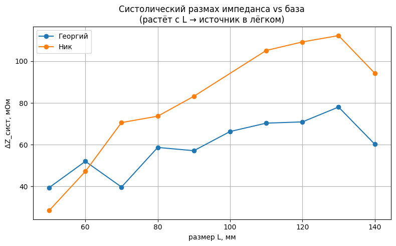

**Анализ результатов.** У обоих испытуемых размах в целом возрастает с размером сборки.

**Результаты и умозаключения.** Форма зависимости подтверждает лёгочное происхождение пульсации; количественное разделение — в §3.

## §3. Разделение приращений Δρ₁ и Δρ₂

**Входные данные.** Систолический размах по размерам из §1 и производные импеданса в рабочей точке.

**Допущения.** Приращения Δρ₁ и Δρ₂ разделяются по системе (11.2). Раздельная оценка по паре сборок плохо обусловлена (угол в плоскости (Δρ₁, Δρ₂) около 9°, см. §0), поэтому наряду с ней приводится проекция (только Δρ₂ при Δρ₁ = 0).

```
субъект  | Δρ1     Δρ2     | проекция ρ2 | спред углов | трактовка
--------------------------------------------------------------------------------------
Георгий  |  0.002   0.073 |  0.098      |   9.3°      | split ненадёжен (см. §4.4) → брать проекцию
Ник      | -0.002   0.086 |  0.066      |   9.1°      | split ненадёжен (см. §4.4) → брать проекцию

Δρ2≈0.07–0.09 Ом·м (~0.4%% от ρ2): пульсовое кровенаполнение лёгкого. Δρ1≈0: мягкие ткани почти не пульсируют.
```

**Анализ результатов.** Совместная оценка даёт Δρ₁ ≈ 0 и Δρ₂ ≈ 0.07–0.09 Ом·м (около 0.4 % от ρ₂); проекция ρ₂ равна 0.065 (Ник) и 0.098 (Георгий). Угол в плоскости приращений мал (9°), поэтому надёжна проекция.

**Результаты и умозаключения.** Пульсовое приращение сосредоточено в лёгком (Δρ₂), приращение мягких тканей (Δρ₁) близко к нулю. Надёжность вывода Δρ₁ ≈ 0 обосновывается формой сигнала (§3.1), а не этой парной оценкой.

## §3.1. Почему Δρ₁ ≈ 0: форма сигнала несовместима с мягкими тканями

**Входные данные.** Систолический размах по размерам и производные ∂Z/∂ρ₁, ∂Z/∂ρ₂ по размерам.

**Допущения.** Чтобы обосновать Δρ₁ ≈ 0 не подгонкой, а формой сигнала, размах поочерёдно описывается только базисом ρ₁ (убывающим с размером) и только базисом ρ₂ (растущим); качество описания оценивается коэффициентом детерминации (11.3). Разделимость определяется углом между L-формами базисов (§0).

```
субъект  | R² (ρ1-only) | R² (ρ2-only) | угол L-форм базисов
------------------------------------------------------------
Георгий  |    -5.66     |    -0.11     | 41°
Ник      |    -2.36     |    +0.76     | 28°
```

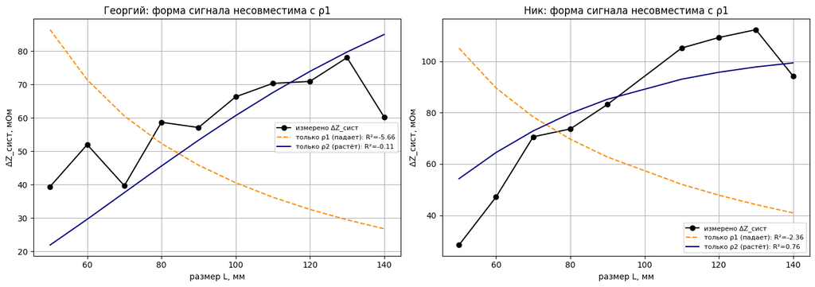

```
Сигнал растёт с L → лёгкое (ρ2). Мягкотканный базис (ρ1, убывающий) даёт R²<0 → Δρ1≈0 обоснован.
```

**Результаты и умозаключения.** Данные исключают мягкотканное происхождение пульсации: возрастание размаха с размером несовместимо с убывающим базисом мягких тканей. Вывод Δρ₁ ≈ 0 обоснован формой сигнала.

## §3.2. Численная граница Δρ₁ по самой мелкой сборке

**Входные данные.** Систолический размах самой мелкой сборки (50 мм) и приращение Δρ₂, оценённое по крупным сборкам; бутстреп-оценка разброса по ударам.

**Допущения.** Самая мелкая сборка наиболее поверхностна (наибольшая ∂Z/∂ρ₁), поэтому даёт верхнюю границу Δρ₁: если приписать весь её размах мягким тканям, получится максимально возможное Δρ₁. Остаток после вычитания вклада лёгкого относят к Δρ₁.

```
субъект  | ΔZ_сист(50)   | Δρ1 верх.гран. | Δρ1 остаток        | Δρ2/ρ2
------------------------------------------------------------------------------
```

```
Георгий  | 39.4±8.0 мОм | 2.35 мОм·м (0.018%) | +1.07±0.48 мОм·м (+0.008%) | 0.48%
Ник      | 28.4±8.2 мОм | 1.56 мОм·м (0.033%) | -1.82±0.45 мОм·м (-0.038%) | 0.45%
```

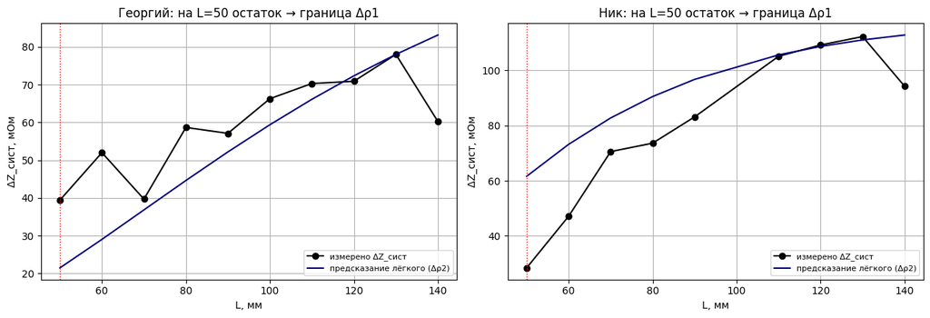

```
Δρ1 разного знака между испытуемыми и |Δρ1|<~0.05%·ρ1 → согласуется с нулём (граница, не значение).
```

**Анализ результатов.** Верхняя граница Δρ₁ составляет 0.033 % от ρ₁ у Ника и 0.018 % у Георгия; остаток равен −1.8 мОм·м у Ника и +1.1 мОм·м у Георгия (разного знака), тогда как Δρ₂/ρ₂ около 0.45 %.

**Результаты и умозаключения.** Правильная форма ответа для Δρ₁ — граница, а не значение: |Δρ₁|/ρ₁ ≲ 0.05 %, в десять с лишним раз меньше по доле, чем Δρ₂/ρ₂. Разный знак остатка подтверждает согласие с нулём.

## §3.3. Оценка, разрешённая по времени, и её предел

**Входные данные.** Усреднённые по зубцам R формы пульсового импеданса и их стандартные ошибки по всем размерам сборок; производные в рабочей точке.

**Допущения.** Чтобы получить наиболее точную оценку, в каждый момент сердечного цикла решается взвешенная задача по всем размерам сборок (11.4); это даёт кривые Δρ₁(t) и Δρ₂(t) с доверительными полосами. Полосы отражают только статистический шум ударов; систематика модели в них не входит.

```
субъект  | пик Δρ2: t / значение±SE / %ρ2 | Δρ1 в этот t ±SE / %ρ1 | t(пик|Δρ1|)
------------------------------------------------------------------------------------------------
Георгий  | 380мс / -0.074±0.008 / -0.40% | +0.0012±0.0007 / +0.009% | 80мс
Ник      | 340мс / -0.084±0.006 / -0.48% | +0.0021±0.0006 / +0.045% | 330мс
```

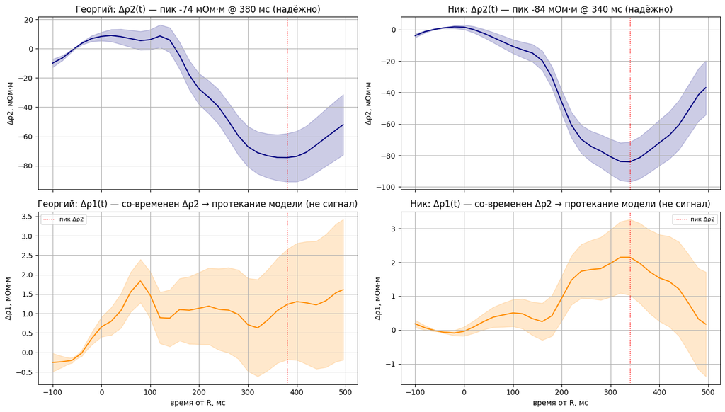

```
ИТОГ: Δρ2 ≈ -0.08 Ом·м (пик ~340 мс), точность ~10%% (статистика).
      Δρ1 со-временен Δρ2 и метод-зависим -> систематика модели; |Δρ1| ≲ 2 мОм·м (≲0.05%% ρ1) — ГРАНИЦА, не значение.
      Полосы = ТОЛЬКО статистический шум; реальный предел Δρ1 — модельная систематика (§4.8 док. 06).
```

**Анализ результатов.** Пик Δρ₂ равен −0.084 Ом·м при 340 мс у Ника и −0.074 Ом·м при 380 мс у Георгия (около −0.08 Ом·м, статистическая точность около 10 %). Δρ₁ в этот момент около +0.002 Ом·м и со-временен пику Δρ₂, что указывает на его артефактность.

**Результаты и умозаключения.** Рабочий результат: Δρ₂ ≈ −0.08 Ом·м (знак отрицателен — приток крови снижает сопротивление), пик около 340 мс. Δρ₁ приводится как граница ≲ 0.05 % ρ₁; его предел — модельная систематика (глубинная структура источника), а не статистика (06 §4.8).

## §3.4. Состав ударов для ансамбля: объединённый и раздельный по задержкам дыхания

Разделы §1–§3.3 усредняют пульсовой импеданс по всем зубцам R записи, то есть совместно по спокойному дыханию, обеим задержкам и глубокому дыханию, тогда как производные ∂Z/∂ρ₁ и ∂Z/∂ρ₂ вычисляются в одной рабочей точке — на вдохе. Настоящий раздел выполняет обе постановки, объединённую и раздельную по состояниям дыхания, сопоставляет их результаты и обосновывает выбор основной оценки.

Результаты §1–§3.3 при этом сохраняются без изменений: они приведены ниже в графе «объединённо» и выгружаются в артефакт `params/systolic.json` наравне с состояние-разрешёнными, чтобы обе оценки оставались доступны последующим расчётам и сопоставимы между собой.

**Входные данные.** Пульсовой импеданс канала 2 (`RHEO_2`, мОм) из записей эксперимента на диске `Z:`; зубцы R и границы режимов дыхания из меток `timestamps/` (08); удельное сопротивление мягких тканей ρ₁ и удельное сопротивление лёгкого на выдохе ρ₂выд из `params/static.json` (09); удельное сопротивление лёгкого на вдохе ρ₂вд из `params/ct.json` (10).

**Допущения.** Разложение (11.2) получено линеаризацией прямой задачи и справедливо лишь в окрестности одной рабочей точки. Производная ∂Z/∂ρ₂ зависит от самого ρ₂, а ρ₂ различается между состояниями дыхания: у испытуемого Ник 17.41 Ом·м на вдохе против 14.71 Ом·м на выдохе (§0, 09 §3). Ансамбль, набранный из ударов разных состояний, соответствует смеси рабочих точек, тогда как делится он на производную, вычисленную в одной. Чтобы устранить это несоответствие, вводится состояние-разрешённая постановка (11.5):

$$\widehat{\Delta\boldsymbol\rho}^{(s)}=\arg\min_{\Delta\rho_1,\Delta\rho_2}\left\|\,J\!\left(\rho_1,\rho_2^{(s)},h\right)\,\Delta\boldsymbol\rho-\Delta\mathbf{Z}^{(s)}\right\|^{2},\qquad s\in\{\text{вдох},\ \text{выдох}\} \tag{11.5}$$

где s — состояние дыхания, задержка вдоха либо задержка выдоха; ΔZ^(s) — вектор систолических размахов по размерам сборок, набранных только из ударов состояния s, Ом; J(ρ₁, ρ₂^(s), h) — матрица производных импеданса по (ρ₁, ρ₂) размерности «размер сборки × параметр», вычисленная в рабочей точке того же состояния; Δρ^(s) — искомые приращения удельного сопротивления, Ом·м.

Приняты дополнительные допущения.

1. Окно ансамбля, отбраковка ударов с ограничением сигнала на пределе измерителя и определение систолического размаха (11.1) сохранены прежними (§1), чтобы различие между вариантами определялось только составом ударов и рабочей точкой.
2. Удары отбираются с отступом 0.5 с от границ плато задержки, чтобы исключить переходные участки.
3. Для испытуемого Георгий ρ₂ на выдохе данными не определяется — оценка выходит на верхний предел (09 §3.1). Рабочая точка выдоха для него получена переносом отношения ρ₂выд/ρ₂вд, измеренного у Ника, на его же ρ₂вд из томографии. Допущение проверяется на устойчивость: результат приводится для трёх значений ρ₂ на выдохе.

```
Георгий — систолический размах ΔZ_сист(L), мОм (в скобках число ударов):
   L,мм | объединённо      | задержка вдоха   | задержка выдоха
     50 |     39.4 (n= 67) |     34.8 (n= 22) |     55.9 (n= 27)
     60 |     52.0 (n= 64) |     43.3 (n= 20) |     46.7 (n= 22)
     70 |     39.7 (n= 72) |     38.1 (n= 14) |     56.9 (n= 25)
     80 |     58.7 (n= 71) |     35.8 (n= 14) |     74.1 (n= 26)
     90 |     57.1 (n= 81) |     34.2 (n= 17) |     77.4 (n= 20)
    100 |     66.3 (n= 84) |     49.2 (n= 21) |     72.4 (n= 26)
    110 |     70.3 (n= 84) |     61.1 (n= 23) |     88.6 (n= 12)
    120 |     70.9 (n= 84) |     43.7 (n= 22) |    111.7 (n= 27)
    130 |     78.0 (n= 85) |     82.3 (n= 20) |     93.0 (n= 29)
    140 |     60.2 (n= 84) |     56.4 (n= 20) |     65.5 (n= 39)

Ник — систолический размах ΔZ_сист(L), мОм (в скобках число ударов):
   L,мм | объединённо      | задержка вдоха   | задержка выдоха
     50 |     28.4 (n= 68) |     58.5 (n= 20) |     19.0 (n= 21)
     60 |     47.2 (n= 68) |     92.2 (n= 19) |     28.3 (n= 22)
     70 |     70.6 (n= 59) |    121.2 (n= 12) |     55.4 (n= 22)
     80 |     73.6 (n= 60) |    112.2 (n= 21) |     55.1 (n= 21)
     90 |     83.2 (n= 62) |    129.8 (n= 20) |     61.4 (n= 21)
    110 |    105.1 (n= 64) |    159.3 (n= 20) |     84.1 (n= 22)
    120 |    109.2 (n= 59) |    160.0 (n= 20) |     92.7 (n= 21)
    130 |    112.3 (n= 64) |    166.8 (n= 20) |     79.3 (n= 24)
    140 |     94.3 (n= 86) |    147.4 (n= 20) |     59.8 (n= 25)

Δρ по трём постановкам (знак положителен, так как взят размах; физически ρ2 за систолу убывает):
субъект   | состав ударов @ точка  |       Δρ1 |       Δρ2 | проекция Δρ2
------------------------------------------------------------------------------
Георгий   | объединённо @ вдох     |   +0.0016 |   +0.0729 |   +0.0978
Георгий   | вдох @ вдох            |   +0.0011 |   +0.0619 |   +0.0789
Георгий   | выдох @ выдох          |   +0.0019 |   +0.0788 |   +0.1147
          | устойчивость выдоха к выбору ρ2: при ρ2выд=18.59 проекция +0.1363, при ρ2выд=15.00 проекция +0.1114
Ник       | объединённо @ вдох     |   -0.0020 |   +0.0857 |   +0.0661
Ник       | вдох @ вдох            |   -0.0016 |   +0.1208 |   +0.1041
Ник       | выдох @ выдох          |   -0.0019 |   +0.0526 |   +0.0390
------------------------------------------------------------------------------
```

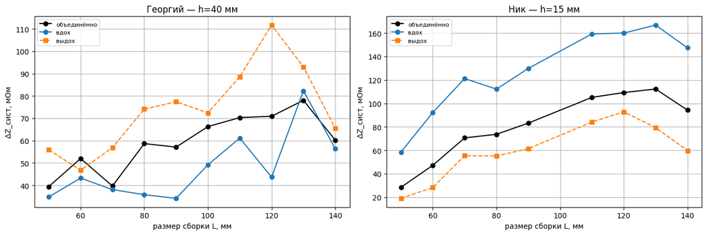

```
→ params/systolic.json записан: обе постановки сохранены как артефакт
```

Различие не объясняется объёмом выборки. Случайная подвыборка из полного набора ударов того же объёма, что и выборка задержки (20 ударов), даёт для Ника при L = 50 мм 39.1 ± 15.8 мОм, то есть воспроизводит объединённое значение 28.4 мОм в пределах разброса и не приближается к значению 58.5 мОм, полученному на задержке вдоха. Следовательно, различие вызвано состоянием дыхания, а не числом усредняемых ударов.

Разделение приращений даёт следующие значения. Для Ника: объединённо Δρ₂ = 0.0857 Ом·м, на вдохе 0.1208, на выдохе 0.0526 Ом·м. Для Георгия: объединённо 0.0729, на вдохе 0.0619, на выдохе 0.0788 Ом·м. Проекция при Δρ₁ = 0 даёт соответственно 0.0661, 0.1041, 0.0390 и 0.0978, 0.0789, 0.1147 Ом·м. Оценка выдоха для Георгия зависит от принятого ρ₂ на выдохе: при переносе отношения от Ника проекция составляет 0.1147 Ом·м, при использовании ρ₂ вдоха 0.1363, при 15.00 Ом·м — 0.1114 Ом·м, то есть неопределённость этого допущения составляет около 20 %.

Приращение удельного сопротивления мягких тканей во всех шести постановках остаётся в пределах от −0.0020 до +0.0019 Ом·м, то есть не превышает 0.04 % от ρ₁ и меняет знак между испытуемыми. Вывод Δρ₁ ≈ 0 (§3.1) от состава ударов не зависит.

Существенно, что совпадение объединённых оценок между испытуемыми (0.0857 и 0.0729 Ом·м) при переходе к состояние-разрешённым распадается: на вдохе 0.1208 против 0.0619, на выдохе 0.0526 против 0.0788 Ом·м. Это указывает, что прежняя близость значений была следствием усреднения по разным смесям состояний, а не совпадением физических величин у двух испытуемых.

**Выбор основной оценки.** Основной принимается состояние-разрешённая оценка на задержке вдоха. Основания приведены по убыванию значимости.

1. Соответствие условиям применимости метода. Разложение (11.2) линейно и справедливо в окрестности одной рабочей точки; только раздельная постановка обеспечивает совпадение состояния данных с состоянием, в котором вычислена матрица производных.
2. Согласованность с остальной работой. Обратная задача статики решается по плато задержек (09 §1, §3), артефакт `params/static.json` содержит величины, отнесённые к задержкам, а томографическая оценка ρ₂ получена на полном вдохе (10). Вдох — единственное состояние, для которого ρ₂ известна независимо от импеданса, что снимает круговую зависимость при вычислении ∂Z/∂ρ₂.
3. Воспроизводимость. Состав объединённого ансамбля определяется тем, сколько ударов пришлось на каждый режим дыхания в конкретной записи. Это не контролируемая величина, поэтому объединённая оценка не воспроизводима между записями и между испытуемыми даже при неизменной физиологии.

Оценка на задержке выдоха сохраняется как второе независимое измерение, но основной не принимается: для Георгия ρ₂ на выдохе не определяется данными, и рабочая точка получена переносом допущения.

Цена выбора — уменьшение числа усредняемых ударов примерно с 59–86 до 12–29, то есть увеличение случайного разброса приблизительно в 1.7 раза. Эта цена меньше устраняемой систематической ошибки, составляющей от 30 % до 120 % величины.

**Результаты и умозаключения.** Основная оценка систолического приращения удельного сопротивления лёгкого: Δρ₂ = −0.121 Ом·м для Ника и −0.062 Ом·м для Георгия (знак отрицателен физически: приток крови снижает удельное сопротивление). Прежние объединённые значения −0.086 и −0.073 Ом·м сохранены в `params/systolic.json` и остаются в §3 как результат другой постановки.

Отсюда следует, что близость систолических приращений у двух испытуемых, отмеченная в §5 и в 00 §5, не подтверждается при согласованном выборе рабочей точки. Одновременно обнаружена величина, ранее не выделявшаяся: зависимость пульсового приращения от наполнения лёгкого, имеющая противоположное направление при тонких и толстых мягких тканях. Её интерпретация требует большего числа испытуемых и в настоящей работе не проводится; для оценки достоверности следует учитывать систематику отдельных сборок (09 §2.2), не устранённую в этих данных.

**Форма представления, устойчивая к калибровке прибора.** Прямая задача однородна первой степени по паре удельных сопротивлений, поэтому ошибка усиления измерительного тракта в γ раз тождественно неотличима от одновременного изменения ρ₁ и ρ₂ в γ раз, а производная ∂Z/∂ρ₂ при этом инвариантна (09 §3.2, формула 9.12). Следовательно измеренное ΔZ и восстановленное Δρ₂ масштабируются тем же множителем, и абсолютные значения в Ом·м определены лишь с точностью до калибровки. Отношение Δρ₂/ρ₂ от неё не зависит:

| Испытуемый | задержка вдоха | задержка выдоха |
| --- | --- | --- |
| Ник | **0.694 %** | 0.369 % |
| Георгий | **0.333 %** | 0.509 % |

Учитывая установленные неисправности прибора (17 §4.2), основной формой представления результата принимается относительная величина, абсолютная приводится как сопровождающая. Четыре относительных значения укладываются в диапазон 0.33–0.69 %, тогда как абсолютные различаются вдвое; при этом противоположное направление зависимости от состояния дыхания у двух испытуемых сохраняется и в относительной форме, то есть не является следствием выбора нормировки.

## §4. Электромеханическая задержка

**Входные данные.** Усреднённые систолические волны и зубцы R; конец электрической систолы по интервалу QT с поправкой Базетта (§0 08).

```
субъект  | R->начало спада | R->пик наполнения | конец эл.систолы (QT, Базетт)
------------------------------------------------------------------------------------
Георгий  |    192 мс       |      320 мс        |    362 мс
Ник      |    120 мс       |      340 мс        |    408 мс
```

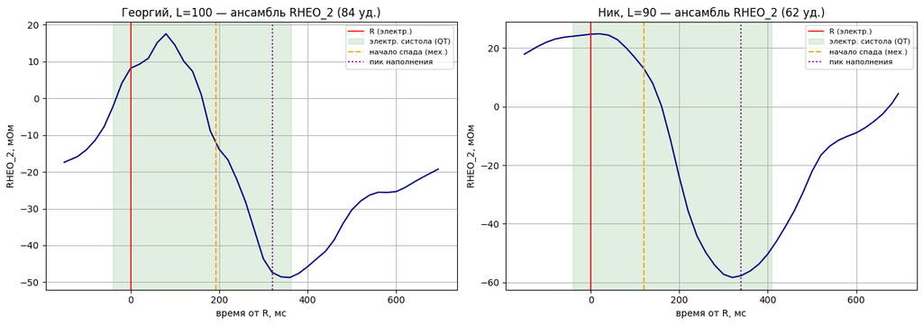

**Анализ результатов.** Пик наполнения лёгкого наступает через 340 мс после зубца R у Ника и 320 мс у Георгия и укладывается в окно электрической систолы (конец QT 408 и 362 мс).

**Результаты и умозаключения.** Пик наполнения запаздывает относительно зубца R на электромеханическую задержку и транзит пульсовой волны и лежит внутри электрической систолы, что согласуется с физиологией. Абсолютная шкала Δρ требует калибровки пульсового тракта (09 §5.2).